# Media Mix Modeling via Dynamic Linear Regression

Econometrics State Space Models Time Series

In this post we discuss the application of Dynamic Linear Regression model to Media Mix Modeling. We adopt a state space representation of the linear regression model and use the dlm R package to fit the model to a media mix modeling example.

# Introduction

Marketers are generally interested in building models that link different marketing variables such as sales activities, operations and external factors, to changes in consumer behavior, such as acquisition, sales, revenue, and retention .Once the model are implemented these can then support the development of forwardlooking business simulations and optimization exercises. When only advertising variables are included in the model this practice is generally called media mix modeling.

One of the models most used in practice for media mix modeling is the linear regression model. Once the regression is fitted and unknown parameters are estimated, it is possible to infer the effect that the different explanatory variables have on the response variable and obtain key information such as marginal estimated contributions and elasticities. One of the key assumptions about the plain linear regression model is that the estimates of the parameters remain constant over the period considered. This assumption appears to be limited in many context, for example in marketing it might be assumed that the marginal effect on budget allocated to different media changes, as the customer behavior or the penetration of one media evolves over time.

In order to overcome this limitation the Dynamic Linear Regression Model (DLM), which allows for time varying parameters represent a powerful alternative to plain linear regression. Once the DLM is casted in State Space form it is possible to estimate the parameters in a dynamic way and conduct a series of inferential procedures.

We will first give an introduction to the State Space models, and then we will show, using the R package dlm, how to fit a DLM to a Media Mix Modeling problem.

# State Space Models

State space models provide a unified methodology for treating a wide range of problems in time series analysis. In this approach it is assumed that the development of the time series under study is determined by an unobserved component $\alpha_{1},\dots,\alpha_{n}$, with which are associated a series of observations $y_{1},\dots,y_{n}$. The unobserved components are called the states of the process and their evolution is assumed to be described by a first order Markov process. The relation between the $\alpha_{t}$’s and the $y_{t}$’s is specified by the state space model. The main purpose of state space analysis is to infer the relevant properties of the $\alpha_{t}$’s from a knowledge of the observations $y_{1},\dots,y_{n}$. The simple linear Gaussian state space model is given by

$$\begin{aligned}
y_{t} &=Z_{t} \alpha_{t}+\varepsilon_{t}, & & \varepsilon_{t} \sim \mathrm{N}\left(0, H_{t}\right) \\
\alpha_{t+1} &=T_{t} \alpha_{t}+R_{t} \eta_{t}, & & \eta_{t} \sim \mathrm{N}\left(0, Q_{t}\right), & t=1, \ldots, n,
\end{aligned}$$
where $y_{t}$ is a $p \times 1$ vector of observations called the observation vector and $\alpha_{t}$ is an unobserved $m \times 1$ vector called the state vector. The idea underlying the model is that the development of the system over time is determined by $\alpha_{t}$ according to the second equation of, but because $\alpha_{t}$ cannot be observed directly we must base the analysis on observations $y_{t}$. The first equation of is called the **observation equation** and the second is called the **state equation**. The matrices $Z_{t}, T_{t}, R_{t}, H_{t} and Q_{t}$ are initially assumed to be known and the error terms $\epsilon_{t}$ and $\eta_{t}$t are assumed to be serially independent and independent of each other at all time points. In practice, some or all of the matrices $Z_{t}, T_{t}, R_{t}, H_{t} and Q_{t}$ will depend on elements of an unknown parameter vector $psi$ that needs to be estimated. Estimation of $\psi$ is generally performed by maximizing the prediction error decomposition form of the likelihood, that is

$$\log L\left(Y_{n}\right)=-\frac{n p}{2} \log 2 \pi-\frac{1}{2} \sum_{t=1}^{n}\left(\log \left|F_{t}\right|+v_{t}^{\prime} F_{t}^{-1} v_{t}\right).$$

In order to obtain the prediction error decomposition of the likelihood the Kalman Filter is generally adopted. The Kalman Filter consists of the following set of recursive equations.

$$\begin{aligned}
v_{t} &=y_{t}-Z_{t} a_{t}, & F_{t} &=Z_{t} P_{t} Z_{t}^{\prime}+H_{t} \\
a_{t \mid t} &=a_{t}+P_{t} Z_{t}^{\prime} F_{t}^{-1} v_{t}, & P_{t \mid t} &=P_{t}-P_{t} Z_{t}^{\prime} F_{t}^{-1} Z_{t} P_{t} \\
a_{t+1} &=T_{t} a_{t}+K_{t} v_{t}, & P_{t+1} &=T_{t} P_{t}\left(T_{t}-K_{t} Z_{t}\right)^{\prime}+R_{t} Q_{t} R_{t}^{\prime}
\end{aligned}$$

The application of the Kalman Filter requires that the initial condition of the systems $\alpha_{1} \sim N(a_{1},P_{1})$ are known. This rarely happens in practice and when the initial conditions of the system are not known a diffuse initialization is adopted. In practice diffuse initialization consists of initialize the distribution of $\alpha_{1}$ with a diffuse prior distribution. When the diffuse initialization is adopted the resulting likelihood is

$$\log L_{d}\left(Y_{n}\right)=-\frac{n p}{2} \log 2 \pi-\frac{1}{2} \sum_{t=1}^{d} w_{t}-\frac{1}{2} \sum_{t=d+1}^{n}\left(\log \left|F_{t}\right|+v_{t}^{\prime} F_{t}^{-1} v_{t}\right)$$

where $w_{t}$ is a variable related to the diffuse initialization, see (Durbin and Koopman 2012) for a detail explanation of the diffuse initialization.

### Filtering, Smoothing and Forecasting

Once a model has been casted in state space it is then possible to perform three different types of “inference”:

- **Filtering**.In Filtering the rucursions of the Kalman Filter are used to recover the states distributions conditioned on the observed series $y_{1}, \dots, y_{T}$, that is, $f(\alpha_{t}|y_{1:T})$.
- **Smoothing**. In Smoothing the interest is to retrospectively reconstruct the behavior of the system. While in filter recursions are taken forward starting from $t = 1$, in this case, we use a backward-recursive algorithm to compute the conditional distributions of $\alpha_{t}$ given $y_{1:T}$ , for any $t < T$, starting from the filtering distribution $f(\alpha_{t} |y_{1:T} )$ and estimating backward all the states history.
- **Forecasting** With y1:t at hand, one can be interested in forecasting future values of the observations, $Y_{t+k}$, or of the state vectors, $\alpha_{t+k}$. For state space models, the recursive form of the computations makes it natural to compute the one-step ahead forecasts and to update them sequentially as new data become available. The one-step ahead forecasts corresponds to $E(Y_{t+1}|y_{1:t})$ for the observed series and to $E(\alpha_{t+1}|\alpha_{1:t})$ for the states.

## Regression with time varying parameters

State Space form represent a natural way to represent a linear regression with time varying parameters. In this case the regression equation represent the observation equation and the parameters are modeled as the unobserved states of the system. The observation equation is formulated as

$$y_{t} = x'_{t}\beta_{t} + \epsilon_{t} \quad \epsilon_{t} \sim N(0,\sigma^{2})$$

where $y_{t}$ is the response variable observed at time $t$, $x_{t}$ is a $k \times 1$ vector of regressors, $\beta_{t}'$ is a $k \times 1$ vector of time varying parameters and $\epsilon_{t}$ is the error term. In order to describe the behavior of the parameters the a state equation must be specified. If the parameters $\beta_{t}$ are assumed follow a random walk model the full specification of the DLM becomes

$$\begin{aligned}
y_{t} &= x'_{t} \beta_{t}+\varepsilon_{t} & & \varepsilon_{t} \sim \mathrm{N}\left(0, \sigma^{2}\right) \\
\beta_{t+1} &= \beta_{t}+\eta_{t} & & \eta_{t} \sim \mathrm{N}\left(0, Q \right) & t=1, \ldots, n,
\end{aligned}$$
where $T_{t} = I$ and $Z_{t} = x'_{t}$. The behavior of the parameters is guided by the matrix $Q$, when $Q = 0$ the model reduces the standard static linear regression model.The specification of the dynamic behavior of the parameters $\beta_{t}$ is generally guided by underlying assumptions or empirical evidence of the phenomena under study. For example when cyclical behavior is observed an autoregressive process of order 2, can be used to model the parameters.That is,

$$\begin{aligned}
y_{t} &= x'_{t} \beta_{t}+\varepsilon_{t} \quad &\varepsilon_{t} \sim \mathrm{N}\left(0, \sigma^{2}_{t}\right) \\
\beta_{t+1} &= \phi_{0} + \phi_{1}\beta_{t-1} + \phi_{2} \beta_{t-2} + \eta_{t} \quad &\eta_{t} \sim N(0,Q).
\end{aligned}$$

# Dynamic Marketing Mix Model

## Data description

The data contains sales (expressed in thousand of units) and the corresponding advertising budget (expressed in thousand of dollars) for several media. The data ranges from 2001/01/01 to 2017/08/01 for a total of 200 observations.

## Preliminary Analysis

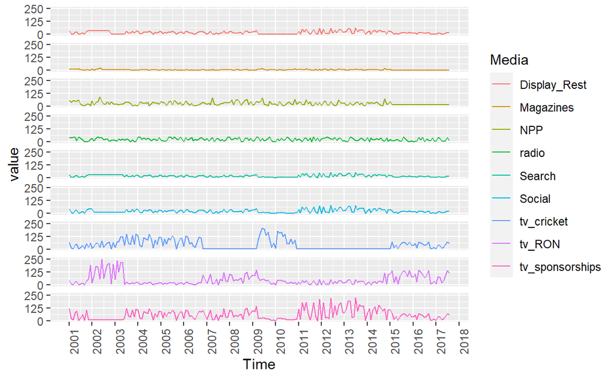

A time series plot reveals that there is a great difference between the budget allocated to the different media. TV represents the media to which more money are allocated and the investments are divided depending on the TV program. Moreover, it emerges clearly that when some media are used other are stopped. In particular overt the period 2009-2011 no budget was allocated to Search and social media but a high investment was allocated to tv_cricket.

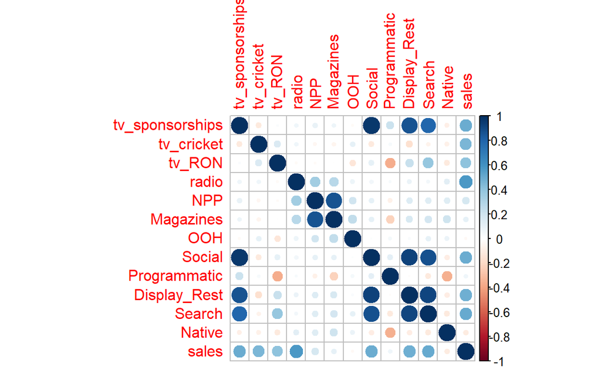

From the correlation matrix it appears that sales are positively correlated with the budget allocated to TV, Radio, Social, Display rest and Search while there is no apparent linear relationship with the other media. TV and Radio represent the classical media more correlated with sales, while Social, Display_Rest and Seaarch are the new media with the highest correlation. As it is evident from the correlation matrix there is a strong positive correlation between the budget allocated to different media.For example there is an high positive correlation between Social, tv_sponsorship, Display_Rest and Search, meaning that when the budget in increased in one of these media is increased also in the others. We proceed to specify the media mix model.

## Media mix model specification

A general model specification for media mix modeling is the standard linear regression model,

$$y_{t} = \mu_{t} + \gamma_{t} + x_{t}'\beta + \epsilon_{t} \quad \epsilon_{t} \sim N(0,\sigma^{2})$$

where $\mu_{t}$ is the trend component representing the long run beahvior of the series, $\gamma_{t}$ is the seasonal component, $x'_{t}$ is the vector of covariates, $\beta$ is the vector of unknown parameter and $\epsilon_{t}$ is the error term. When no seasonal behavior or trend are detected or assumed in the series the model reduces to

$$y_{t} = x'_{t}\beta + \epsilon_{t} \quad \epsilon_{t} \sim N(0,\sigma^{2}).$$

As stated in the introduction one limitation of the plain linear regression model is that the marginal effects of the explanatory variables, represented by $\beta$, remains constant over time. Nevertheless, in some context, it might be more natural to allow the vector $\beta$ to evolve with time. In this example we will consider the following model

where the behavior of the parameters is modeled as a random walk process.

## Fittinig dynamic models in R: the dlm package

The package that we will use to fit the dynamic linear model is the dlm package, developed by Giovanni Petris, which provides a flexible environment for fitting Dynamic Linear Gaussian models. Before to be fitted the data needs to be transformed into a ts object. Since we are working with monthly data we set the frequency equal to 12.

```
# convert the data to a ts object
adv.ts <- ts(advertising, start = advertising$Time[1], frequency = 12)
```

Next, we extract the response variable (sales) and the explanatory variables, and proceed to fit the model and obtain the filtered and the smoothed states.

```
x <-  adv.ts[,2:13]
y <-  adv.ts[,14]

# Define the linear regression model
# Logarithmic transformation is applied to variance components to increase
# the stability of the Kalman Filter
buildTVREG <-  function(parm, x.mat){
  # parametrize the model as log(variance)
  parm <- exp(parm)
  # return function output
  return(dlmModReg(X = x.mat, dV = parm[1], dW = parm[2:14]))
}

# Set initial values for optimizer
start.values = rep(0,14)

# Obtain maximum likelihood estimates
TVREG.mle = dlmMLE(y = y, parm = start.values, x.mat = x, buildTVREG)
```

In order to be sure that the optimizer converged we check the convergence criterion

```
TVREG.mle$convergence
```

```
[1] 0
```

A zero values represent that the optimizer converged. The resulting estimated variances are

```
 [1] 1.190284e+00 7.784013e-01 1.509632e+02 5.487937e+01 4.844075e+00
 [6] 2.106967e+03 2.454546e+01 9.248649e-02 1.956561e-35 8.046326e+00
[11] 5.258666e+02 3.476090e+00 9.725586e+02 1.729687e+00
```

The estimated variances can be built into the model to obtain the filtered and the smoothed states, which in our dynamic linear model correspond to the unknown time varying parameters.

```
# Assign parameters to the estimated model
TVREG.dlm <- buildTVREG(TVREG.mle$par,x)

# Obtain fitlered states
TVREG.f <- dlmFilter(y,TVREG.dlm)

# Obtain smoothed states
TVREG.s <-  dlmSmooth(TVREG.f)
```

Once the smoothed states are calculated we proceed to plot them over the period considered.

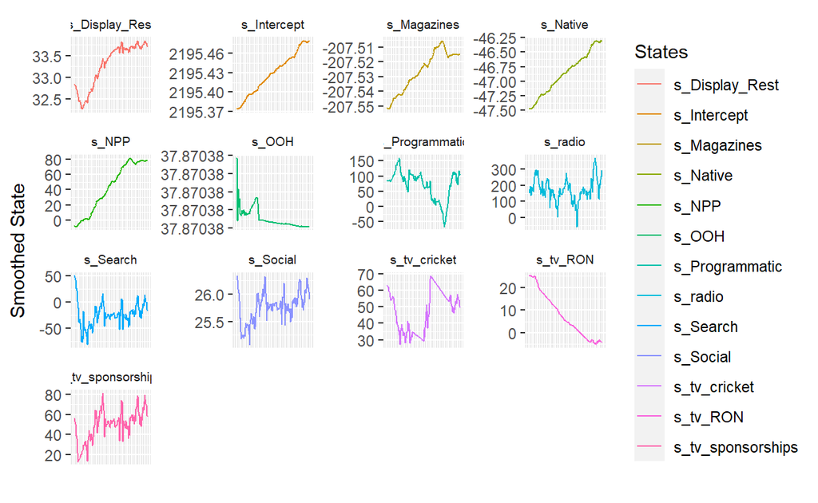

Figure 1: Smoothed states

```
# Extract smoothed states
s = TVREG.s$s

Time = advertising$Time
# Assign column names to the smoothed states
colnames(s) <- paste("s", sep = "_",c("Intercept",colnames(x)))

# Plot the smoothed states
s  %>% as_tibble() %>%
  filter(between(row_number(),1,n()-1)) %>%
  mutate(Time = Time) %>%
  pivot_longer(cols = -c("Time"), names_to = "States") %>%
  ggplot(aes (x = Time, y = value, color = States)) +
  geom_line() +
  ylab("Smoothed State") +
  xlab("")+
  facet_wrap(.~States, scales = "free") +
 scale_x_date(date_breaks = "1 year",date_labels = "%Y") +
  theme(strip.background = element_blank(),
        strip.text.x = element_text(size = 7),
  axis.text.x = element_blank(),
  axis.ticks.x = element_blank())
```

Figure 1 shows all the smoothed states over the period considered. The smoothed intercept represent the expected volume of sales when no budget is allocated to any media while the other states represent the unitary increase in sales when another dollar is allocated to the corresponding media. It is apparent that the variability in the smoothed states is different among the different media. The intercept shows an upward trend over the entire period, however the size of the increment is particularly small and to refine the model a fixed parameter restriction seems reasonable. The marginal effect of Magazines and Native is negative for the entire period while those of Search and Programmatic alternates from negative to positive values. Overall tv_cricket, tv_sponsorships, Radio and Social appear the safest media to which allocate budget. Overall despite new media represent good opportunities, traditional media appear to be more reliable form of investment. It is important to note that despite NPP is only slightly correlated to sales the corresponding estimated parameter shows a steady positive trend.

## Elasticities

Once the model is estimated we can use it to calculate the elasticity of sales to the different media. The price elasticity (PED) is a measure of the responsiveness of the quantity demanded of a good to a change in its price When PED is greater than one, demand is elastic. This can be interpreted as consumers being very sensitive to changes with respect to a given variable $x$: a $1\%$ increase in $x$ will lead to a drop in quantity demanded of more than $1\%$. When PED is less than one, demand is inelastic. This can be interpreted as consumers being insensitive to changes in $x$: a $1\%$ increase in price will lead to a drop in quantity demanded of less than $1\%$. Given that the estimated model is

$$\widehat{sales}_{t} = \hat{\beta}_{0t} + \sum_{j=1}^{k} x_{jt} \times \hat{\beta}_{jt}$$

where each $\beta_{t}$ is modeled as a random walk process, the elasticity of sales with respect to a media can be obtained as

$$E_{jt} = \frac{\Delta sales}{\Delta x_{j}} \times \frac{x_{j}}{sales} = \beta_{jt} \frac{\overline{x}_{j}}{\overline{sales}}.$$

where $\overline{x}_{j}$ and $\overline{sales}$ represent the mean of the $j$th explanatory variable and of the sales. Another common approach to estimate elasticity with regression models is to adopt a double log transformation, which result in a model of the form

$$log(y_{t}) = log(x'_{t})\beta + \epsilon_{t}.$$
Under this transformation the estimated parameter $\hat{\beta}$ correspond to the value of the elasticity.

We proceed to compute the elasticity of sales with the media that appeared more correlated to them.

```
# Obtain the elasticities from the smoothed states
elasticities <- s %>% as_tibble() %>%
  filter(between(row_number(),1,n()-1)) %>%
  cbind(advertising) %>%
  # calculate elasticities
  mutate(tv_cricket_el = s_tv_cricket*(mean(tv_cricket)/mean(sales)),
         tv_RON_el = s_tv_RON*(mean(tv_RON)/mean(sales)),
         tv_sponsor_el = s_tv_sponsorships*(mean(tv_sponsorships)/mean(sales)),
         Radio_el = s_radio*(mean(radio)/mean(sales)),
         Social_el = s_Social*(mean(Social)/mean(sales)),
         Display_el = s_Display_Rest*(mean(Display_Rest)/mean(sales)),
         Search_el = s_Search*(mean(Search)/mean(sales))) %>%
  # select time and elasticities
  select(Time,contains("el"))
```

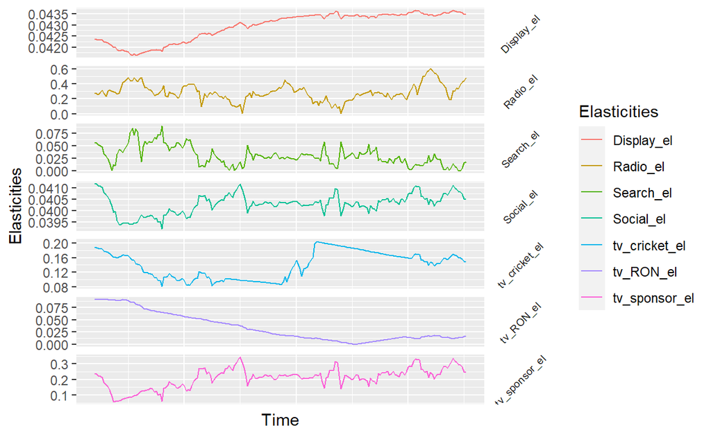

Figure 2: Estimated elasticities

It appears that sales are inelastic to all the media shown in figure 2.This means that the sales increase less than proportionally to the investment of the corresponding media. In other words a $1\%$ increase in investment in of the media considered produces an increase of less than $1\%$ in sales. The sales elasticity to Display shows an increasing trend while the sales elasticity to tv_Ron, on the opposite, shows a negative trend that reaches 0. Overall the classical media: rv_sponsorship, tv_cricket and Radio are the media with the highest elasticity.

[output not shown]

The predictions obtained modeling the states as random walks are not really informative as in this case the best forecast is simply equal to previous period value. The adoption of a different stochastic process such as a random walk with drift or an autoregressive process to model the state (in this case the parameters) dynamics could be more useful for this purpose.

Chan, David, and Mike Perry. 2017. “Challenges and Opportunities in Media Mix Modeling.”

Durbin, James, and Siem Jan Koopman. 2012. *Time Series Analysis by State Space Methods*. Oxford university press.

Harvey, Andrew C, and Clara Fernandes. 1989. “Time Series Models for Count or Qualitative Observations.” *Journal of Business & Economic Statistics* 7 (4): 407–17.

Petris, Giovanni, Sonia Petrone, and Patrizia Campagnoli. 2009. “Dynamic Linear Models.” In *Dynamic Linear Models with R*, 31–84. Springer.